# DREAM: which drugs look like trametinib?

GSE197555 A549 signature queried against LINCS 2020 with signatureSearch

The Connectivity Map idea: if a drug’s expression signature in cells looks like the trametinib signature, the drug probably hits the same biology; if it looks like the opposite, it pushes the pathway the other way. Here the A549 trametinib signature is compared with every compound signature in LINCS 2020 (136,460 signatures from about 30,000 compounds in 58 cell lines, moderated z-scores on 12,328 genes).

CLUE.io, the original query service, has been retired, so the query runs locally with signatureSearch’s implementation of the LINCS connectivity score. `scripts/download_lincs.sh` fetches the reference file (6.3 GB) and checks its sha256.

Because trametinib and several other MEK inhibitors are in LINCS, the query has a built-in positive control: they should come out as the strongest mimics.

```r
library(signatureSearch)
library(rhdf5)
library(fgsea)
library(tidyverse)

dir.create(file.path(params$outdir, "figures"), recursive = TRUE, showWarnings = FALSE)
theme_set(theme_bw(base_size = 12))
```

## Query signature

The LINCS method takes an up set and a down set of Entrez genes. The strongest 150 up and down genes by shrunken fold change are used (padj < 0.05, baseMean ≥ 100), keeping only genes measured in LINCS.

```r
lincs_genes <- as.character(h5read(params$lincs, "rownames"))
de <- read_tsv(params$deseq2, show_col_types = FALSE) |>
  mutate(entrez = as.character(entrez)) |>
  filter(padj < 0.05, baseMean >= 100, entrez %in% lincs_genes) |>
  distinct(entrez, .keep_all = TRUE)
up <- de |> filter(log2FC_shrunk > 0) |> slice_max(log2FC_shrunk, n = params$n_genes)
down <- de |> filter(log2FC_shrunk < 0) |> slice_min(log2FC_shrunk, n = params$n_genes)
write_tsv(bind_rows(up = up, down = down, .id = "set") |> select(set, gene_id, symbol, entrez, log2FC_shrunk, padj),
          file.path(params$outdir, "query_signature.tsv"))
tibble(up = nrow(up), down = nrow(down), lincs_genes = length(lincs_genes))
```

```
# A tibble: 1 × 3
     up  down lincs_genes
  <int> <int>       <int>
1   150   150       12328
```

## Connectivity query

Each reference signature (one compound in one cell line) gets a weighted connectivity score (WTCS), normalised within cell line and direction to give NCS. Positive NCS means the compound mimics the trametinib signature; negative means it reverses it.

```r
qsig <- qSig(query = list(upset = up$entrez, downset = down$entrez), gess_method = "LINCS", refdb = params$lincs)
res <- gess_lincs(qsig, sortby = "NCS", tau = FALSE, workers = params$workers, addAnnotations = FALSE)

data("lincs_pert_info2")
annot <- lincs_pert_info2 |> distinct(pert_id, .keep_all = TRUE) |> select(pert_id, pert_iname, MOA, target, max_phase)
hits <- result(res) |>
  as_tibble() |>
  left_join(annot, by = c(pert = "pert_id")) |>
  mutate(pert_iname = coalesce(pert_iname, pert))
write_tsv(hits, file.path(params$outdir, "lincs_connectivity.tsv.gz"))
tibble(signatures = nrow(hits), compounds = n_distinct(hits$pert_iname), cell_lines = n_distinct(hits$cell))
```

```
# A tibble: 1 × 3
  signatures compounds cell_lines
       <int>     <int>      <int>
1     136460     29680         58
```

## Compound ranking

About two thirds of signatures score exactly 0: the LINCS method sets the score to zero when the up and down genes move the same way. A per-signature median is therefore 0 for most compounds. Instead each compound gets signatureSearch’s summary across cell lines, NCSct: the 67th or 33rd percentile of its NCS values, whichever is larger in magnitude. Compounds with fewer than 3 signatures are dropped.

```r
cmp <- hits |>
  group_by(pert) |>
  summarise(pert_iname = first(pert_iname), NCSct = first(NCSct), signatures = n(), cell_lines = n_distinct(cell),
            MOA = first(MOA), target = first(target), max_phase = first(max_phase), .groups = "drop") |>
  filter(signatures >= 3) |>
  arrange(desc(NCSct)) |>
  mutate(rank = row_number(),
         control = if_else(str_detect(coalesce(MOA, ""), fixed(params$positive_control_moa)),
                           params$positive_control_moa, "other"))
write_tsv(cmp, file.path(params$outdir, "compound_ranking.tsv"))
```

## Positive control: MEK inhibitors

Each compound counts once in the test, because one compound’s signatures across cell lines are not independent.

```r
ctrl_test <- wilcox.test(NCSct ~ control, data = cmp |> mutate(control = fct_relevel(control, params$positive_control_moa)),
                         alternative = "greater")
ctrl <- cmp |> group_by(control) |> summarise(compounds = n(), median_NCSct = median(NCSct), .groups = "drop")
ctrl
```

```
# A tibble: 2 × 3
  control       compounds median_NCSct
  <chr>             <int>        <dbl>
1 MEK inhibitor        17         1.32
2 other             13188         0
```

```r
ctrl_test$p.value
```

```
[1] 2.701847e-10
```

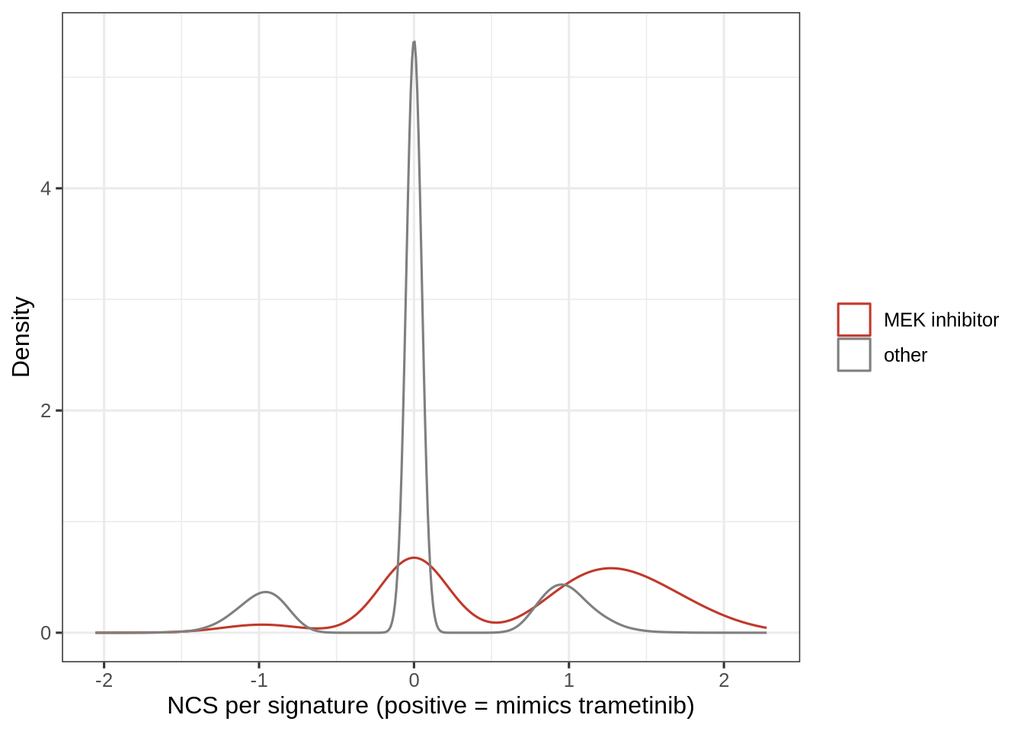

```r
p_ctrl <- hits |>
  mutate(control = if_else(pert %in% cmp$pert[cmp$control != "other"], params$positive_control_moa, "other")) |>
  ggplot(aes(NCS, colour = control)) +
  geom_density() +
  scale_colour_manual(values = setNames(c("#c0392b", "grey50"), c(params$positive_control_moa, "other"))) +
  labs(x = paste0("NCS per signature (positive = mimics ", params$treatment, ")"), y = "Density", colour = NULL)
ggsave(file.path(params$outdir, "figures", "positive_control.png"), p_ctrl, width = 6, height = 3.5, dpi = 150)
p_ctrl
```

```r
cmp |> filter(control != "other") |>
  select(rank, pert, pert_iname, NCSct, signatures, max_phase) |>
  knitr::kable(digits = 2, caption = paste("Compounds annotated", params$positive_control_moa, "(rank out of", nrow(cmp), ")"))
```

Compounds annotated MEK inhibitor (rank out of 13205 )

| rank | pert | pert_iname | NCSct | signatures | max_phase |
| --- | --- | --- | --- | --- | --- |
| 1 | BRD-K64538373 | Ro-4987655 | 1.59 | 13 | NA |
| 2 | BRD-A50454580 | PD-0325901 | 1.48 | 14 | 0 |
| 3 | BRD-K85751432 | refametinib | 1.44 | 15 | NA |
| 5 | BRD-K46419649 | U-0126 | 1.43 | 13 | 0 |
| 6 | BRD-K26667523 | TAK-733 | 1.42 | 14 | NA |
| 8 | BRD-K89014967 | AS-703026 | 1.39 | 22 | 2 |
| 11 | BRD-K12343256 | trametinib | 1.35 | 26 | 4 |
| 12 | BRD-K49865102 | PD-0325901 | 1.35 | 32 | 0 |
| 14 | BRD-K05104363 | PD-184352 | 1.32 | 25 | 2 |
| 15 | BRD-K88677950 | PD-198306 | 1.31 | 14 | 0 |
| 45 | BRD-K62810658 | PD-98059 | 1.20 | 23 | 0 |
| 84 | BRD-K18787491 | U-0126 | 1.14 | 27 | 0 |
| 85 | BRD-K57080016 | selumetinib | 1.14 | 42 | 4 |
| 565 | BRD-K73368362 | BIX-02189 | 0.93 | 21 | NA |
| 4991 | BRD-K06753942 | nobiletin | 0.00 | 14 | 0 |
| 7735 | BRD-K53523901 | arctigenin | 0.00 | 15 | 0 |
| 9992 | BRD-K91701654 | U-0126 | 0.00 | 14 | 0 |

```r
# The query is only trustworthy if drugs with the same mechanism come out as mimics
stopifnot(ctrl$median_NCSct[ctrl$control == params$positive_control_moa] > 0, ctrl_test$p.value < 0.05)
```

**Reading:** the 17 MEK inhibitor compounds have a median NCSct of 1.3, against 0 for the other 13,188 (Wilcoxon p ≈ 3e-10), and they take 10 of the top 20 ranks, including 1, 2, 3, 5 and 6. Rank 4 is AZD-8330, a MEK inhibitor that simply lacks a mechanism annotation in LINCS. In A549 itself, selumetinib, PD-0325901 and trametinib each reach NCS 2.1-2.2. The weak scorers are compounds annotated MEK inhibitor for indirect or off-target reasons (arctigenin, nobiletin) and BIX-02189, which targets MEK5 rather than MEK1/2. The A549 RNA-seq signature and the LINCS L1000 profiles come from different labs and platforms, so this agreement shows the query recovers mechanism, not just matching noise.

## Mechanism-of-action enrichment

Compounds are grouped by annotated mechanism and tested for enrichment at the top (mimics) or bottom (reversers) of the ranking.

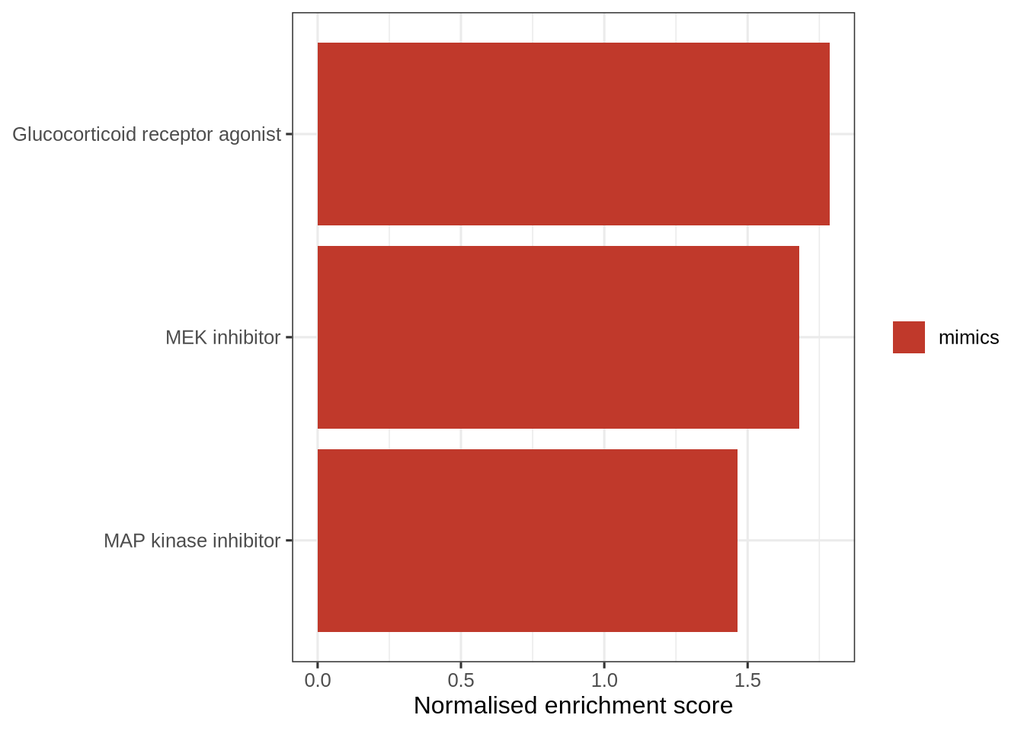

```r
moa_sets <- cmp |>
  filter(!is.na(MOA)) |>
  separate_longer_delim(MOA, ";") |>
  mutate(MOA = str_trim(MOA)) |>
  (\(x) split(x$pert, x$MOA))()
set.seed(1)
moa <- fgsea(moa_sets, setNames(cmp$NCSct, cmp$pert), minSize = 5, maxSize = 500) |>
  as_tibble() |>
  arrange(pval)
write_tsv(moa |> mutate(leadingEdge = map_chr(leadingEdge, \(x) paste(cmp$pert_iname[match(x, cmp$pert)], collapse = ";"))),
          file.path(params$outdir, "moa_enrichment.tsv"))

p_moa <- moa |>
  filter(padj < 0.05) |>
  slice_max(abs(NES), n = 25) |>
  mutate(pathway = fct_reorder(pathway, NES)) |>
  ggplot(aes(NES, pathway, fill = NES > 0)) +
  geom_col() +
  scale_fill_manual(values = c(`TRUE` = "#c0392b", `FALSE` = "#2471a3"), labels = c(`TRUE` = "mimics", `FALSE` = "reverses"), name = NULL) +
  labs(x = "Normalised enrichment score", y = NULL)
ggsave(file.path(params$outdir, "figures", "moa_enrichment.png"), p_moa, width = 7, height = 6, dpi = 150)
p_moa
```

```r
cmp |> filter(str_detect(coalesce(MOA, ""), "RAF inhibitor")) |>
  select(rank, pert_iname, NCSct, signatures) |>
  knitr::kable(digits = 2, caption = "RAF inhibitors")
```

RAF inhibitors

| rank | pert_iname | NCSct | signatures |
| --- | --- | --- | --- |
| 27 | AZ-628 | 1.26 | 37 |
| 36 | CEP-32496 | 1.23 | 7 |
| 60 | GW-5074 | 1.17 | 8 |
| 172 | SB-590885 | 1.06 | 11 |
| 287 | regorafenib | 1.01 | 23 |
| 768 | SB-590885 | 0.88 | 19 |
| 5054 | GW-5074 | 0.00 | 38 |
| 5568 | PLX-4720 | 0.00 | 19 |
| 6005 | sorafenib | 0.00 | 24 |
| 6380 | PP-30 | 0.00 | 20 |
| 7516 | sorafenib | 0.00 | 18 |
| 8555 | GDC-0879 | 0.00 | 27 |
| 12899 | vemurafenib | -0.95 | 32 |
| 13070 | dabrafenib | -1.03 | 23 |

## Repurposing candidates

Approved drugs (clinical phase 4) that mimic the trametinib signature without being annotated to the RAF–MEK–ERK axis. These are drugs whose effect on cells resembles MEK blockade through some other route.

```r
mapk_axis <- "MEK inhibitor|RAF inhibitor|ERK inhibitor|MAP kinase inhibitor"
cand <- cmp |>
  filter(max_phase == 4, NCSct > 0, !str_detect(coalesce(MOA, ""), mapk_axis)) |>
  distinct(pert_iname, .keep_all = TRUE) |>
  slice_head(n = 20)
write_tsv(cand, file.path(params$outdir, "repurposing_candidates.tsv"))
cand |> select(rank, pert_iname, MOA, target, NCSct, cell_lines) |> knitr::kable(digits = 2)
```

| rank | pert_iname | MOA | target | NCSct | cell_lines |
| --- | --- | --- | --- | --- | --- |
| 24 | dexamethasone | Glucocorticoid receptor agonist | NR3C1 | 1.27 | 3 |
| 32 | capecitabine | DNA synthesis inhibitor; Thymidylate synthase inhibitor | TYMS | 1.24 | 3 |
| 46 | mometasone | Glucocorticoid receptor agonist | NR3C1 | 1.20 | 13 |
| 48 | fluocinolone-acetonide | Corticosteroid agonist; Glucocorticoid receptor agonist | NR3C1 | 1.20 | 7 |
| 129 | neratinib | EGFR inhibitor | EGFR; ERBB2; ERBB4 | 1.09 | 28 |
| 133 | beclomethasone-dipropionate | Immunosuppressant; Glucocorticoid receptor agonist | NR3C1 | 1.09 | 8 |
| 205 | ixazomib | Proteasome inhibitor | PSMB1 | 1.04 | 27 |
| 221 | budesonide | Glucocorticoid receptor agonist | NR3C1 | 1.03 | 9 |
| 307 | loteprednol | Phospholipase inhibitor; Glucocorticoid receptor agonist | NR3C1 | 1.00 | 7 |
| 325 | estrone | Estrogen receptor agonist | ESR1 | 1.00 | 3 |
| 376 | triamcinolone | Glucocorticoid receptor agonist | NR3C1 | 0.98 | 8 |
| 395 | naltrexone | Opioid receptor antagonist | OPRD1; OPRK1; OPRM1 | 0.97 | 14 |
| 416 | sulfathiazole | NA | NA | 0.97 | 3 |
| 496 | bosutinib | Src inhibitor; Abl kinase inhibitor | ABL1; HCK; LYN; BCR; SRC; CAMK2G | 0.95 | 37 |
| 601 | raloxifene | Estrogen receptor antagonist; Selective estrogen receptor modulator | ESR1; ESR2 | 0.92 | 22 |
| 715 | toremifene | Estrogen receptor antagonist; Selective estrogen receptor modulator | ESR1 | 0.90 | 8 |
| 751 | fludrocortisone-acetate | Glucocorticoid receptor agonist; Mineralocorticoid receptor agonist | NR3C2 | 0.89 | 9 |
| 777 | betamethasone | Glucocorticoid receptor agonist | NR3C1 | 0.88 | 14 |
| 781 | CS-1657 | PARP inhibitor | PARP1 | 0.88 | 9 |
| 811 | bromfenac | Cyclooxygenase inhibitor | PTGS1; PTGS2 | 0.87 | 8 |

**Reading:** the approved list is dominated by glucocorticoids (dexamethasone, mometasone, budesonide and others), plus neratinib (EGFR/HER2, upstream of MEK) and bosutinib (Src/Abl). These are hypotheses, not recommendations: a matching expression signature does not show anti-tumour effect, and the steroids’ high scores may partly reflect a shared anti-inflammatory programme (the trametinib signature also lowers interferon and NF-kB targets). Some have three signatures only (dexamethasone, capecitabine), so their scores are the least stable.